# Antibiotic knowledge score in Serbian primary-care attenders

Dataset 1: Antibiotic knowledge and self-medication in Serbia

RSR feasibility analysis

2026-08-03

# Introduction

Antibiotic resistance in south-eastern Europe is driven in part by how the general public uses antibiotics, and public knowledge is the usual target of national stewardship campaigns. These data come from a cross-sectional questionnaire survey of 500 adults who consulted general practitioners at four health centres in Serbia, reported by Horvat and colleagues (*PLOS ONE* 2017;12(7):e0180799). Each respondent answered a 12-item quiz about what antibiotics are for and how they should be taken, scored 0 to 12. Knowing which groups score poorly tells campaign designers where to aim.

**Aim.** Among Serbian adults attending primary care, we examined which of age group, sex, education, employment status, frequency of GP contact and having a health professional in the family are independently associated with the antibiotic knowledge score, mutually adjusting for the others.

This is a *Purpose 3* analysis: several predictors are of interest and the question is which remain associated with the outcome after mutual adjustment.

# Methods

**Data source.** Cross-sectional, interviewer-administered questionnaire survey of adults consulting general practitioners at four Serbian health centres; 500 respondents completed the entire questionnaire and all 500 are analysed here. All measurements were taken on a single occasion, so this is a snapshot rather than a follow-up study.

**Variables.** The outcome is `knowledge_score`, the total antibiotic knowledge score in points on a 0-12 scale, where higher means better knowledge; in this sample it runs from 2 to 12. Predictors are `age_group` (six bands; reference: over 65, the largest band at n = 123), `sex` (reference: female, the majority at n = 304), `education_level` (primary / secondary / tertiary; reference: secondary, the largest group at n = 259), `employment_status` (reference: employed, n = 251), `gp_visits_past_year` (four bands of visits in the previous 12 months; reference: none, the group with no primary-care contact, n = 135) and `health_professional_in_family` (reference: no, n = 374). All six are categorical, so every estimate is a difference in mean score against the stated reference level; there are no continuous predictors and therefore no per-unit slopes.

Two of the eight available background variables were left out deliberately. `marital_status` is largely a restatement of age in this sample (Cramér’s V = 0.55 with `age_group`: nearly all the divorced or widowed respondents are in the older bands), so it would add two parameters and inflate the variance of the age contrasts without adding a distinct construct. `household_size` is a three-band count with no plausible mechanism linking it to what a person knows about antibiotics, and it is unrelated to the outcome here (univariable p = 0.37). `id` is a row number and is never modelled.

`adequate_knowledge` is **not** used, in either direction. It is the indicator `knowledge_score >= 9` and nothing else: in this file the respondents flagged 0 score 2 to 8 and those flagged 1 score 9 to 12, and re-deriving the flag from the score reproduces the deposited column exactly (`identical()` returns TRUE). Putting it in a model for `knowledge_score` would be circular, and the reverse — modelling `adequate_knowledge` on `knowledge_score` — is complete separation. The two columns are one outcome measured two ways, continuous and dichotomised, and only one of them can be the response in any given analysis.

**Statistical analysis.** Linear regression (`lm()`), justified because the outcome is a continuous count of correct answers spanning 2 to 12 points with a roughly unimodal distribution. We fitted a univariable model for each predictor first, then a single multivariable model containing all of them. Predictors were chosen in advance on subject-matter grounds, not by significance. Significance threshold 0.05; estimates are reported with 95% confidence intervals. Assumptions were checked with `performance::check_model()`. Analysis used R version 4.6.0 (2026-04-24) with tidyverse, gtsummary and performance.

**Missing data.** There is none. Every one of the 12 columns is 100% complete, so the complete-case model uses all 500 of 500 rows and 0 were dropped. The survey retained only respondents who completed the entire questionnaire, so there is no missing-data story to tell here — but note that this is itself a form of selection, since partial responders were excluded before the file was created and nothing is known about them.

# Results

## Sample characteristics

**Table 1. Sample characteristics.**

| **Characteristic** | **N** | **N = 500**<sup>1</sup> |
| --- | --- | --- |
| knowledge_score | 500 | 9.00 (8.00, 10.00) |
| age_group | 500 |  |
| Over 65 |  | 123 (25%) |
| 18-24 |  | 25 (5.0%) |
| 25-34 |  | 78 (16%) |
| 35-44 |  | 70 (14%) |
| 45-54 |  | 104 (21%) |
| 55-64 |  | 100 (20%) |
| sex | 500 |  |
| Female |  | 304 (61%) |
| Male |  | 196 (39%) |
| education_level | 500 |  |
| Secondary |  | 259 (52%) |
| Primary |  | 38 (7.6%) |
| Tertiary |  | 203 (41%) |
| employment_status | 500 |  |
| Employed |  | 251 (50%) |
| Unemployed |  | 114 (23%) |
| Pensioner |  | 135 (27%) |
| gp_visits_past_year | 500 |  |
| None |  | 135 (27%) |
| 1-4 |  | 223 (45%) |
| 5-10 |  | 72 (14%) |
| More than 10 |  | 70 (14%) |
| health_professional_in_family | 500 | 126 (25%) |

<sup>1</sup> Median (Q1, Q3); n (%)

The sample skews older and female: about a quarter are over 65 and 61% are women. Education is concentrated in the secondary and tertiary bands, with only 38 respondents educated to primary level. The median knowledge score is 9 of 12 (IQR 8 to 10), so the typical respondent answers about three-quarters of the items correctly and the scale is used mainly in its upper half.

## Exploratory figure

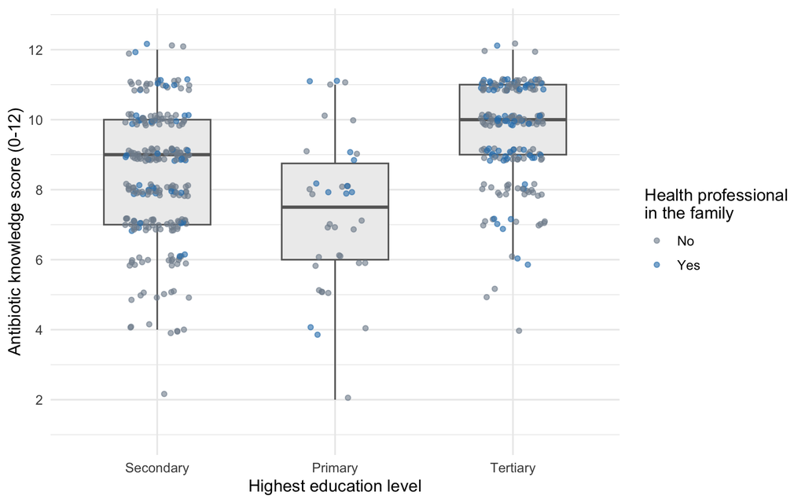

Figure 1. Antibiotic knowledge score by education level, with respondents split by whether a family member works in health care. Boxes show medians and interquartile ranges; points are individual respondents.

Knowledge rises steadily across the three education bands, and within every band the respondents with a health professional in the family sit slightly higher; the primary-education group is both the lowest-scoring and much the smallest, so its box is based on only 38 people.

## Univariable models

| **Characteristic** | **N** | **Beta** | **95% CI** | **p-value** |
| --- | --- | --- | --- | --- |
| age_group | 500 |  |  |  |
| Over 65 |  | — | — |  |
| 18-24 |  | 1.3 | 0.50, 2.0 | 0.001 |
| 25-34 |  | 1.3 | 0.81, 1.8 | <0.001 |
| 35-44 |  | 1.6 | 1.0, 2.1 | <0.001 |
| 45-54 |  | 0.93 | 0.47, 1.4 | <0.001 |
| 55-64 |  | 1.1 | 0.67, 1.6 | <0.001 |
| sex | 500 |  |  |  |
| Female |  | — | — |  |
| Male |  | -0.24 | -0.57, 0.09 | 0.2 |
| education_level | 500 |  |  |  |
| Secondary |  | — | — |  |
| Primary |  | -1.1 | -1.7, -0.53 | <0.001 |
| Tertiary |  | 1.2 | 0.91, 1.5 | <0.001 |
| employment_status | 500 |  |  |  |
| Employed |  | — | — |  |
| Unemployed |  | -0.36 | -0.76, 0.03 | 0.073 |
| Pensioner |  | -1.1 | -1.4, -0.69 | <0.001 |
| gp_visits_past_year | 500 |  |  |  |
| None |  | — | — |  |
| 1-4 |  | -0.31 | -0.70, 0.09 | 0.13 |
| 5-10 |  | -0.51 | -1.0, 0.01 | 0.055 |
| More than 10 |  | -0.75 | -1.3, -0.22 | 0.005 |
| health_professional_in_family | 500 |  |  |  |
| No |  | — | — |  |
| Yes |  | 0.67 | 0.30, 1.0 | <0.001 |

Abbreviation: CI = Confidence Interval

Education is by far the strongest crude predictor. Relative to secondary education, tertiary education is associated with a 1.22 (95% CI 0.91 to 1.54, p < 0.001) point higher score, while primary education is associated with a -1.11 (95% CI -1.69 to -0.53, p < 0.001) point difference — a spread of close to two points on a 12-point scale, and on its own education accounts for R² = 0.157 of the variance (p < 0.001). Age is the next strongest (p < 0.001, R² = 0.090): every younger band scores above the over-65s, for example the 18-24 group by 1.26 (95% CI 0.50 to 2.02, p = 0.001) points. Having a health professional in the family is associated with a 0.67 (95% CI 0.30 to 1.04, p < 0.001) point advantage (p < 0.001), and employment status is also associated crudely (p < 0.001, driven by pensioners scoring low). GP visits are only marginally associated (p = 0.032) and sex is not associated at all (p = 0.153).

## Why adjustment is needed

The crude estimates above are not independent of each other, because the background variables in this survey travel together in a very specific way. `age_group` is the clearest confounder of the education association: 28 of the 38 primary-educated respondents (74%) are over 65, a legacy of when compulsory schooling expanded in the region, and age is itself associated with lower knowledge scores. Without adjustment, part of what looks like an education effect is simply the age composition of the education groups. `employment_status` confounds in the same direction and is almost a restatement of age at the top end: 100 of the 135 pensioners (74%) are over 65, and Cramér’s V between age and employment is 0.58, so the crude pensioner deficit in knowledge may be nothing more than the age effect wearing a different label. A third, weaker route runs through `gp_visits_past_year`: older respondents attend far more often (62% of the over-65s report five or more visits, against 18% of everyone else), so any crude association between GP contact and knowledge is partly an age association. Adjusting for all six simultaneously is what turns these into within-stratum comparisons — the education contrast becomes “comparable respondents of the same age and employment status”, which is the question stewardship campaigns actually need answered.

## Multivariable model

| **Characteristic** | **Beta** | **95% CI** | **p-value** |
| --- | --- | --- | --- |
| age_group |  |  |  |
| Over 65 | — | — |  |
| 18-24 | 1.1 | 0.21, 1.9 | 0.014 |
| 25-34 | 0.68 | 0.01, 1.4 | 0.047 |
| 35-44 | 1.0 | 0.34, 1.7 | 0.003 |
| 45-54 | 0.41 | -0.21, 1.0 | 0.2 |
| 55-64 | 0.71 | 0.17, 1.3 | 0.011 |
| sex |  |  |  |
| Female | — | — |  |
| Male | -0.20 | -0.51, 0.10 | 0.2 |
| education_level |  |  |  |
| Secondary | — | — |  |
| Primary | -0.87 | -1.5, -0.27 | 0.005 |
| Tertiary | 1.0 | 0.70, 1.4 | <0.001 |
| employment_status |  |  |  |
| Employed | — | — |  |
| Unemployed | 0.03 | -0.38, 0.44 | 0.9 |
| Pensioner | -0.12 | -0.66, 0.41 | 0.6 |
| gp_visits_past_year |  |  |  |
| None | — | — |  |
| 1-4 | -0.06 | -0.44, 0.32 | 0.8 |
| 5-10 | 0.11 | -0.42, 0.63 | 0.7 |
| More than 10 | 0.16 | -0.39, 0.72 | 0.6 |
| health_professional_in_family |  |  |  |
| No | — | — |  |
| Yes | 0.52 | 0.17, 0.86 | 0.003 |

Abbreviation: CI = Confidence Interval

Model fit

| Statistic | Value |
| --- | --- |
| R-squared | 0.211 |
| Adjusted R-squared | 0.188 |
| Residual SE | 1.660 |
| N | 500.000 |
| Model df | 14.000 |
| Observations per parameter | 35.700 |

Adjusting for all six predictors, education remains the dominant association: conditional on age, sex, employment, GP contact and family health-care exposure, tertiary education is associated with a 1.03 (95% CI 0.70 to 1.36, p < 0.001) point higher score than secondary education, and primary education with a -0.87 (95% CI -1.47 to -0.27, p = 0.005) point difference. Having a health professional in the family retains an independent 0.52 (95% CI 0.17 to 0.86, p = 0.003) point advantage. The age contrasts survive adjustment in attenuated form — the 18-24 band scores 1.05 (95% CI 0.21 to 1.89, p = 0.014) points above the over-65s and the 35-44 band 1.00 (95% CI 0.34 to 1.67, p = 0.003) — but employment status no longer carries any information once age is in the model (pensioner versus employed: -0.12 (95% CI -0.66 to 0.41, p = 0.649)). Neither sex (-0.20 (95% CI -0.51 to 0.10, p = 0.195)) nor any GP-visit contrast is associated. The model explains R² = 0.211 of the variance in knowledge score (adjusted R² = 0.188), with a residual SD of 1.66 points against a raw SD of 1.84: real, but most of what makes one respondent better informed than another is not captured by demography.

## Unadjusted versus adjusted

**Table 2. Unadjusted and adjusted estimates.**

| **Characteristic** | **Unadjusted** **N** | **Unadjusted** **Beta** | **Unadjusted** **95% CI** | **Unadjusted** **p-value** | **Adjusted** **Beta** | **Adjusted** **95% CI** | **Adjusted** **p-value** |
| --- | --- | --- | --- | --- | --- | --- | --- |
| age_group | 500 |  |  |  |  |  |  |
| Over 65 |  | — | — |  | — | — |  |
| 18-24 |  | 1.3 | 0.50, 2.0 | 0.001 | 1.1 | 0.21, 1.9 | 0.014 |
| 25-34 |  | 1.3 | 0.81, 1.8 | <0.001 | 0.68 | 0.01, 1.4 | 0.047 |
| 35-44 |  | 1.6 | 1.0, 2.1 | <0.001 | 1.0 | 0.34, 1.7 | 0.003 |
| 45-54 |  | 0.93 | 0.47, 1.4 | <0.001 | 0.41 | -0.21, 1.0 | 0.2 |
| 55-64 |  | 1.1 | 0.67, 1.6 | <0.001 | 0.71 | 0.17, 1.3 | 0.011 |
| sex | 500 |  |  |  |  |  |  |
| Female |  | — | — |  | — | — |  |
| Male |  | -0.24 | -0.57, 0.09 | 0.2 | -0.20 | -0.51, 0.10 | 0.2 |
| education_level | 500 |  |  |  |  |  |  |
| Secondary |  | — | — |  | — | — |  |
| Primary |  | -1.1 | -1.7, -0.53 | <0.001 | -0.87 | -1.5, -0.27 | 0.005 |
| Tertiary |  | 1.2 | 0.91, 1.5 | <0.001 | 1.0 | 0.70, 1.4 | <0.001 |
| employment_status | 500 |  |  |  |  |  |  |
| Employed |  | — | — |  | — | — |  |
| Unemployed |  | -0.36 | -0.76, 0.03 | 0.073 | 0.03 | -0.38, 0.44 | 0.9 |
| Pensioner |  | -1.1 | -1.4, -0.69 | <0.001 | -0.12 | -0.66, 0.41 | 0.6 |
| gp_visits_past_year | 500 |  |  |  |  |  |  |
| None |  | — | — |  | — | — |  |
| 1-4 |  | -0.31 | -0.70, 0.09 | 0.13 | -0.06 | -0.44, 0.32 | 0.8 |
| 5-10 |  | -0.51 | -1.0, 0.01 | 0.055 | 0.11 | -0.42, 0.63 | 0.7 |
| More than 10 |  | -0.75 | -1.3, -0.22 | 0.005 | 0.16 | -0.39, 0.72 | 0.6 |
| health_professional_in_family | 500 |  |  |  |  |  |  |
| No |  | — | — |  | — | — |  |
| Yes |  | 0.67 | 0.30, 1.0 | <0.001 | 0.52 | 0.17, 0.86 | 0.003 |

Abbreviation: CI = Confidence Interval

## Diagnostics

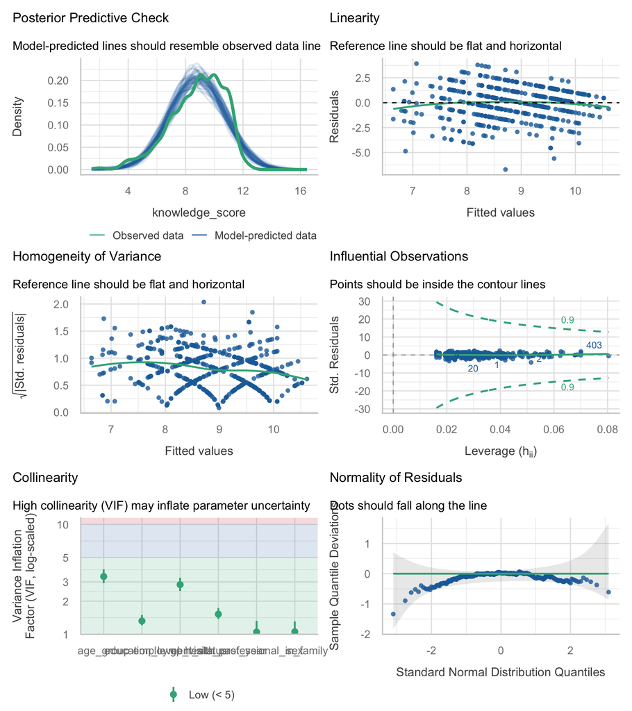

| Term | VIF | VIF_CI_low | VIF_CI_high | SE_factor | Tolerance | Tolerance_CI_low | Tolerance_CI_high |
| --- | --- | --- | --- | --- | --- | --- | --- |
| age_group | 3.359636 | 2.922197 | 3.896625 | 1.128832 | 0.2976513 | 0.2566324 | 0.3422083 |
| sex | 1.053457 | 1.009274 | 1.308135 | 1.026380 | 0.9492558 | 0.7644470 | 0.9908113 |
| education_level | 1.321549 | 1.208696 | 1.495428 | 1.072188 | 0.7566879 | 0.6687051 | 0.8273380 |
| employment_status | 2.831347 | 2.476495 | 3.271482 | 1.297174 | 0.3531888 | 0.3056719 | 0.4037965 |
| gp_visits_past_year | 1.525251 | 1.377524 | 1.730785 | 1.072894 | 0.6556298 | 0.5777726 | 0.7259404 |
| health_professional_in_family | 1.049161 | 1.007427 | 1.325399 | 1.024285 | 0.9531430 | 0.7544897 | 0.9926277 |

Two assumptions fail formally and both trace back to the same feature of the outcome. Homogeneity of variance is rejected (`check_heteroscedasticity()`, p < 0.001): because the score is capped at 12 and most respondents sit near the top, groups with high fitted means have less room to vary than groups with low fitted means, which shows up as a funnel in the fitted-versus-residual panel. Normality of residuals is also rejected (p < 0.001); the Q-Q plot bends at the lower tail, driven by the handful of respondents scoring 2 to 5. Neither is fatal at n = 500 — the central limit theorem protects the coefficient estimates and the intervals are only mildly affected — but a robust (sandwich) standard error would be the honest fix, and this is the single most important caveat on the model. The linearity panel is uninformative here because every predictor is categorical, so the fitted values take only a few dozen distinct levels. Collinearity is acceptable: the largest VIF is 3.36 (age_group), which is elevated by the age-employment overlap described above but stays well below the conventional threshold of 5. No observation is influential (largest Cook’s distance 0.062, far below 0.5). The posterior-predictive panel shows the model’s simulated data are smoother than the observed score distribution, which is expected: the outcome is an integer count of correct answers and the model treats it as continuous.

# Discussion

Among Serbian adults attending primary care, formal education is the characteristic most strongly and independently associated with antibiotic knowledge: tertiary-educated respondents score about a point higher than secondary-educated ones and primary-educated respondents nearly a point lower, and this gradient is not explained away by age, employment or health-service contact. Having a family member who works in health care is worth roughly half a point independently, which is a plausible informal-information effect. Age matters somewhat, sex and frequency of GP visits do not, and the apparent knowledge deficit among pensioners disappears entirely once age is accounted for. Practically, this argues for stewardship messaging pitched at low-literacy audiences and delivered outside the consultation, since attending the GP more often does not appear to make people better informed.

**Future work.** A campaign-evaluation design measuring the same 12-item score before and after a stewardship intervention, in the same respondents, would separate stable educational differences from modifiable knowledge gaps.

# Feasibility notes

*Not part of a student report.*

- **Works well, and is the best of the three outcomes in this file.** `knowledge_score` is complete for all 500 rows, spans 2-12 of a possible 0-12, and produces a clean mix of strongly significant (education, family health professional), partly significant (age) and clearly null (sex, GP visits) predictors — exactly the spread a Purpose 3 exercise needs.
- **Complete-case N = 500** of 500; 0 dropped. The file is 100% complete, so there is genuinely no missing-data narrative available. Students who are expected to write a missing-data paragraph should be told to say so plainly rather than invent one.
- **The trap in this file is `adequate_knowledge`.** It is exactly `knowledge_score >= 9` (verified: `identical()` = TRUE; the 0-group spans 2-8 and the 1-group 9-12). Used as a predictor here it gives R² = 0.68 on its own; used as the outcome with `knowledge_score` as predictor it is perfect separation. Every student working on this dataset will need warning.
- **All predictors are categorical.** There is not one continuous predictor in the file, so no analysis of this dataset can demonstrate a per-unit slope, and the `check_model()` linearity panel is meaningless. That is a real teaching limitation, not a defect of this particular model.
- **Diagnostics fail formally**: heteroscedasticity p < 0.001, normality p < 0.001, both driven by the ceiling at 12. Visually mild and harmless at this n, but a student running `check_model()` will get two red warnings and needs to know what to do with them.
- **Collinearity is present but tolerable**: `age_group` and `employment_status` overlap heavily (Cramér’s V 0.58; 74% of pensioners are over 65), max VIF 3.36. Adding `marital_status` as well (V = 0.55 with age) pushes this further and is best avoided.
- **Modest R² (0.211)**, which is normal for a demographics-only survey model but will disappoint students expecting a “strong” model.